# coding-2

```python
import os
import os.path
import yfinance as yf
from datetime import datetime
import numpy as np
import pandas as pd
import matplotlib
import matplotlib.pyplot as plt
import seaborn as sns
from prettytable import PrettyTable

import warnings
warnings.filterwarnings('ignore')
```

```python
# get stock data and store the data in csv files
def GetStockData(
    StockNa,
    start = datetime(2010, 1, 2),
    end = datetime.today(),
    return_df = False
) :
    # check whether folder exists
    if not os.path.isdir('stockdata') :
        os.mkdir('stockdata')

    # data file name
    filename = 'stockdata/Stock_Price_' + StockNa + '.csv'

    # delete the file if it exists
    if os.path.exists(filename) :
        os.remove(filename)

    # Download history stock price between start date and end date from the source
    df = yf.download(StockNa, start, end)

    # Save the data to csv file
    df.to_csv(filename)

    if return_df :
        return df
```

```python
GetStockData("^gspc", start = datetime(2008, 1, 1), end = datetime(2020, 12, 31))
GetStockData("aapl", start = datetime(2008, 1, 1), end = datetime(2020, 12, 31))
GetStockData("jpm", start = datetime(2008, 1, 1), end = datetime(2020, 12, 31))
GetStockData("pfe", start = datetime(2008, 1, 1), end = datetime(2020, 12, 31))
```

```
[*********************100%***********************]  1 of 1 completed
[*********************100%***********************]  1 of 1 completed
[*********************100%***********************]  1 of 1 completed
[*********************100%***********************]  1 of 1 completed
```

## 1. Common Risk Measures

```python
# Empirical CDF, F_{n}(X)
def CDF(
    data,
    X
) :
    return np.sum(data <= X) / len(data)

# Risk Measures

# 1. Value at Risk (VaR)
def VaR(
    data,
    alpha = 0.05,
) :
    return np.percentile(data, alpha * 100)

# 2. Tail Value at Risk (TVaR)
def TVaR(
    data,
    alpha = 0.05,
) :
    var = VaR(data, alpha)
    return var + np.mean(data[data >= var] - var)

# 3. Conditional Tail Expectation (CTE)
def CTE(
    data,
    alpha = 0.05,
) :
    return np.mean(data[data >= VaR(data, alpha)])

# 4. Conditional Value at Risk (CVaR)
def CVaR(
    data,
    alpha = 0.05,
) :
    var = VaR(data, alpha)
    # E[X-VaR|X>=VaR]
    return np.mean(data[data >= var] - var)

# 5. Expected Shortfall (ES)
def ES(
    data,
    alpha = 0.05,
) :
    var = VaR(data, alpha)
    return np.mean(np.maximum(0, data - var))


# Since we are measuring risks, we use Left-tail Risk Measures

# 1. Left-tail VaR
def LVaR(
    data,
    alpha = 0.05,
) :
    return np.percentile(data, (1- alpha) * 100)

# 2. Left-tail TVaR
def LTVaR(
    data,
    alpha = 0.05,
) :
    var = LVaR(data, alpha)
    return var + np.mean(data[data <= var] - var)

# 3. Left-tail CTE
def LCTE(
    data,
    alpha = 0.05,
) :
    return np.mean(data[data <= LVaR(data, alpha)])

# 4. Left-tail CVaR
def LCVaR(
    data,
    alpha = 0.05,
) :
    var = LVaR(data, alpha)
    return np.mean(data[data <= var] - var)

# 5. Left-tail ES
def LES(
    data,
    alpha = 0.05,
) :
    var = LVaR(data, alpha)
    return np.mean(np.minimum(0, data - var))
```

## We will use Left tail version for our analysis on losses.

### a. 2016-2017, Pre-Pandemic Period

```python
SP500_df_1 = yf.download("^gspc", start = datetime(2016, 1, 1), end = datetime(2017, 12, 31))
aapl_df_1 = yf.download("aapl", start = datetime(2016, 1, 1), end = datetime(2017, 12, 31))
jpm_df_1 = yf.download("jpm", start = datetime(2016, 1, 1), end = datetime(2017, 12, 31))
pfe_df_1 = yf.download("pfe", start = datetime(2016, 1, 1), end = datetime(2017, 12, 31))
```

```
[*********************100%***********************]  1 of 1 completed
[*********************100%***********************]  1 of 1 completed
[*********************100%***********************]  1 of 1 completed
[*********************100%***********************]  1 of 1 completed
```

```python
SP500_return_1 = SP500_df_1["Close"].pct_change().dropna().values
AAPL_return_1 = aapl_df_1["Close"].pct_change().dropna().values
jpm_return_1 = jpm_df_1["Close"].pct_change().dropna().values
pfe_return_1 = pfe_df_1["Close"].pct_change().dropna().values

SP500_cul_return_1 = ((1 + SP500_df_1["Close"].pct_change().dropna()).cumprod() - 1).values
AAPL_cul_return_1 = ((1 + aapl_df_1["Close"].pct_change().dropna()).cumprod() - 1).values
jpm_cul_return_1 = ((1 + jpm_df_1["Close"].pct_change().dropna()).cumprod() - 1).values
pfe_cul_return_1 = ((1 + pfe_df_1["Close"].pct_change().dropna()).cumprod() - 1).values

pd.DataFrame({
    "Date": SP500_df_1.index,
    "SP500": SP500_df_1["Close"],
    "AAPL": aapl_df_1["Close"],
    "JPM": jpm_df_1["Close"],
    "PFE": pfe_df_1["Close"],
    "SP500_daily_return": np.insert(SP500_return_1, 0, np.nan),
    "AAPL_return": np.insert(AAPL_return_1, 0, np.nan),
    "JPM_return": np.insert(jpm_return_1, 0, np.nan),
    "PFE_return": np.insert(pfe_return_1, 0, np.nan),
    "SP500_cum_return": np.insert(SP500_cul_return_1, 0, np.nan),
    "AAPL_cum_return": np.insert(AAPL_cul_return_1, 0, np.nan),
    "JPM_cum_return": np.insert(jpm_cul_return_1, 0, np.nan),
    "PFE_cum_return": np.insert(pfe_cul_return_1, 0, np.nan),
}).to_csv("stockdata/stock_return_pre_COVID.csv", index = False)
```

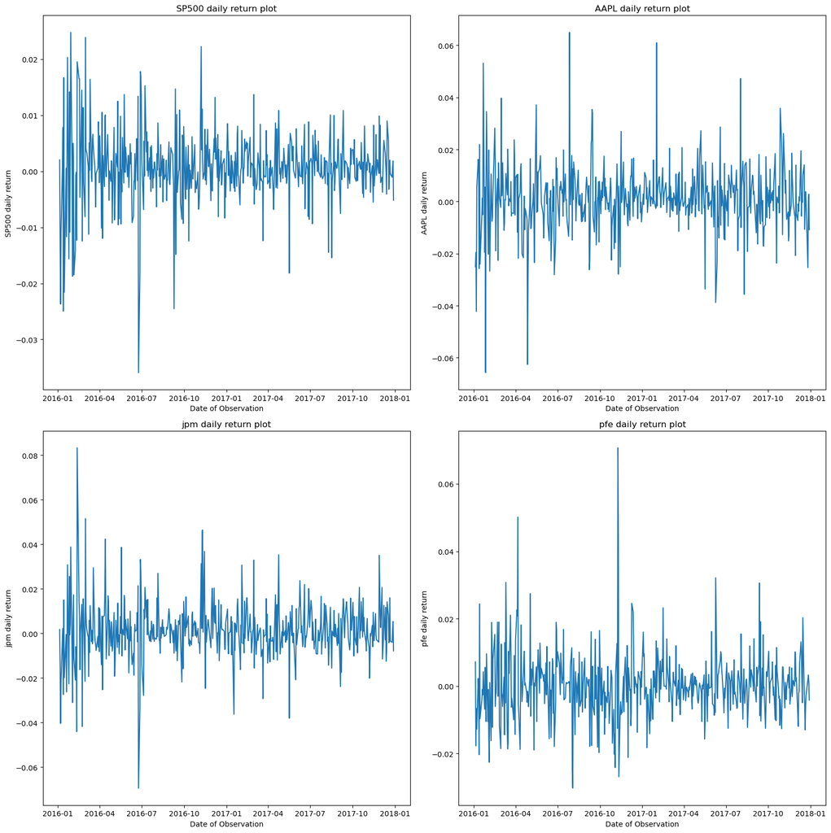

```python
fig, ((ax1, ax2), (ax3, ax4)) = plt.subplots(2, 2, figsize=(16,16))

ax1.plot(SP500_df_1.index[1:], SP500_return_1)
ax1.set_xlabel('Date of Observation')
ax1.set_ylabel('SP500 daily return')
ax1.set_title('SP500 daily return plot')

ax2.plot(aapl_df_1.index[1:], AAPL_return_1)
ax2.set_xlabel('Date of Observation')
ax2.set_ylabel('AAPL daily return')
ax2.set_title('AAPL daily return plot')

ax3.plot(jpm_df_1.index[1:], jpm_return_1)
ax3.set_xlabel('Date of Observation')
ax3.set_ylabel('jpm daily return')
ax3.set_title('jpm daily return plot')

ax4.plot(pfe_df_1.index[1:], pfe_return_1)
ax4.set_xlabel('Date of Observation')
ax4.set_ylabel('pfe daily return')
ax4.set_title('pfe daily return plot')
plt.tight_layout()
plt.show()
```

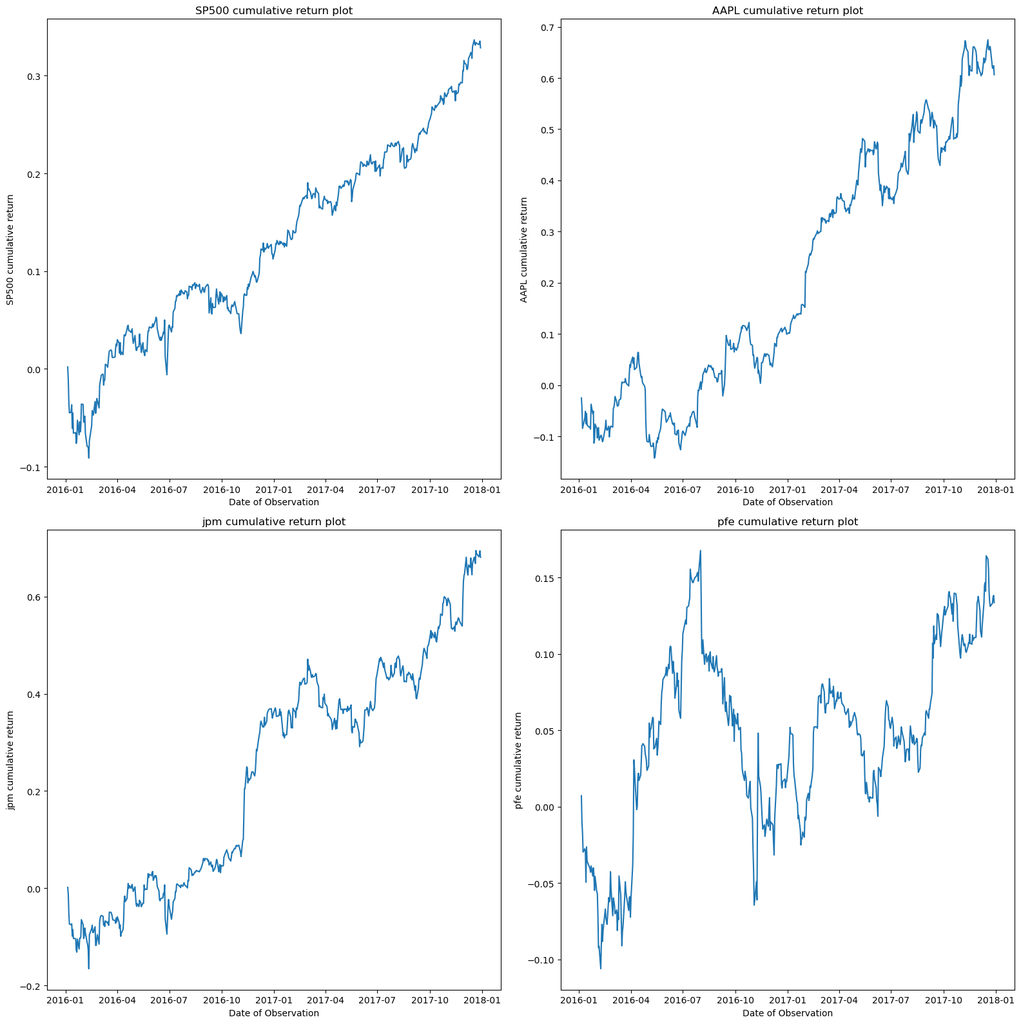

```python
fig, ((ax1, ax2), (ax3, ax4)) = plt.subplots(2, 2, figsize=(16,16))

ax1.plot(SP500_df_1.index[1:], SP500_cul_return_1)
ax1.set_xlabel('Date of Observation')
ax1.set_ylabel('SP500 cumulative return')
ax1.set_title('SP500 cumulative return plot')

ax2.plot(aapl_df_1.index[1:], AAPL_cul_return_1)
ax2.set_xlabel('Date of Observation')
ax2.set_ylabel('AAPL cumulative return')
ax2.set_title('AAPL cumulative return plot')

ax3.plot(jpm_df_1.index[1:], jpm_cul_return_1)
ax3.set_xlabel('Date of Observation')
ax3.set_ylabel('jpm cumulative return')
ax3.set_title('jpm cumulative return plot')

ax4.plot(pfe_df_1.index[1:], pfe_cul_return_1)
ax4.set_xlabel('Date of Observation')
ax4.set_ylabel('pfe cumulative return')
ax4.set_title('pfe cumulative return plot')
plt.tight_layout()
plt.show()
```

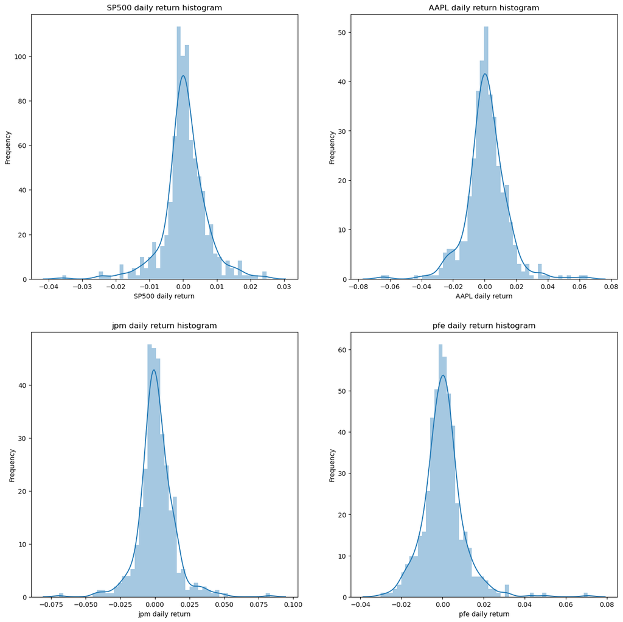

```python
fig, ((ax1, ax2), (ax3, ax4)) = plt.subplots(2, 2, figsize=(16,16))

sns.distplot(SP500_return_1, bins=50, kde=True, ax=ax1)
ax1.set_xlabel('SP500 daily return')
ax1.set_ylabel('Frequency')
ax1.set_title('SP500 daily return histogram')

sns.distplot(AAPL_return_1, bins=50, kde=True, ax=ax2)
ax2.set_xlabel('AAPL daily return')
ax2.set_ylabel('Frequency')
ax2.set_title('AAPL daily return histogram')

sns.distplot(jpm_return_1, bins=50, kde=True, ax=ax3)
ax3.set_xlabel('jpm daily return')
ax3.set_ylabel('Frequency')
ax3.set_title('jpm daily return histogram')

sns.distplot(pfe_return_1, bins=50, kde=True, ax=ax4)
ax4.set_xlabel('pfe daily return')
ax4.set_ylabel('Frequency')
ax4.set_title('pfe daily return histogram')
plt.show()
```

### 1.1a Risk Measures at 95 percent

```python
# 95% Left tail VaR, TVaR, CTE, CVaR for SP500
print("SP500: ")
print("95% Left tail VaR:  {:10.6f}".format(LVaR(SP500_return_1, 0.95)))
print("95% Left tail TVaR: {:10.6f}".format(LTVaR(SP500_return_1, 0.95)))
print("95% Left tail CTE:  {:10.6f}".format(LCTE(SP500_return_1, 0.95)))
print("95% Left tail CVaR: {:10.6f}".format(LCVaR(SP500_return_1, 0.95)))
print("95% Left tail ES:   {:10.6f}".format(LES(SP500_return_1, 0.95)))


# 95% Left tail VaR, TVaR, CTE, CVaR for AAPL
print("AAPL: ")
print("95% Left tail VaR:  {:10.6f}".format(LVaR(AAPL_return_1, 0.95)))
print("95% Left tail TVaR: {:10.6f}".format(LTVaR(AAPL_return_1, 0.95)))
print("95% Left tail CTE:  {:10.6f}".format(LCTE(AAPL_return_1, 0.95)))
print("95% Left tail CVaR: {:10.6f}".format(LCVaR(AAPL_return_1, 0.95)))
print("95% Left tail ES:   {:10.6f}".format(LES(AAPL_return_1, 0.95)))

# 95% Left tail VaR, TVaR, CTE, CVaR for JPM
print("JPM: ")
print("95% Left tail VaR:  {:10.6f}".format(LVaR(jpm_return_1, 0.95)))
print("95% Left tail TVaR: {:10.6f}".format(LTVaR(jpm_return_1, 0.95)))
print("95% Left tail CTE:  {:10.6f}".format(LCTE(jpm_return_1, 0.95)))
print("95% Left tail CVaR: {:10.6f}".format(LCVaR(jpm_return_1, 0.95)))
print("95% Left tail ES:   {:10.6f}".format(LES(jpm_return_1, 0.95)))

# 95% Left tail VaR, TVaR, CTE, CVaR for PFE
print("JPM: ")
print("95% Left tail VaR:  {:10.6f}".format(LVaR(pfe_return_1, 0.95)))
print("95% Left tail TVaR: {:10.6f}".format(LTVaR(pfe_return_1, 0.95)))
print("95% Left tail CTE:  {:10.6f}".format(LCTE(pfe_return_1, 0.95)))
print("95% Left tail CVaR: {:10.6f}".format(LCVaR(pfe_return_1, 0.95)))
print("95% Left tail ES:   {:10.6f}".format(LES(pfe_return_1, 0.95)))
```

```
SP500:
95% Left tail VaR:   -0.009554
95% Left tail TVaR:  -0.016069
95% Left tail CTE:   -0.016069
95% Left tail CVaR:  -0.006515
95% Left tail ES:    -0.000337
AAPL:
95% Left tail VaR:   -0.020717
95% Left tail TVaR:  -0.029570
95% Left tail CTE:   -0.029570
95% Left tail CVaR:  -0.008853
95% Left tail ES:    -0.000459
JPM:
95% Left tail VaR:   -0.018757
95% Left tail TVaR:  -0.028751
95% Left tail CTE:   -0.028751
95% Left tail CVaR:  -0.009995
95% Left tail ES:    -0.000518
JPM:
95% Left tail VaR:   -0.015211
95% Left tail TVaR:  -0.019397
95% Left tail CTE:   -0.019397
95% Left tail CVaR:  -0.004186
95% Left tail ES:    -0.000217
```

### 1.1b Risk Measure Plots

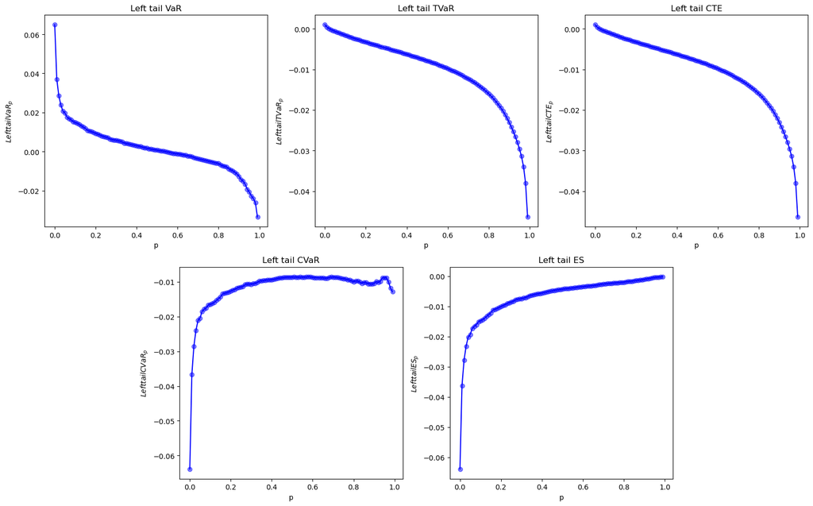

```python
p = np.arange(0, 1, 0.01)
VaR_p = [LVaR(AAPL_return_1, alpha = i) for i in p]
TVaR_p = [LTVaR(AAPL_return_1, alpha = i) for i in p]
CTE_p = [LCTE(AAPL_return_1, alpha = i) for i in p]
CVaR_p = [LCVaR(AAPL_return_1, alpha = i) for i in p]
ES_p = [LES(AAPL_return_1, alpha = i) for i in p]
# fig, ax = plt.subplots(2, 2, figsize = (16,16))
fig = plt.figure(figsize=(16, 10))
spec = matplotlib.gridspec.GridSpec(ncols=6, nrows=2) # 6 columns evenly divides both 2 & 3

ax1 = fig.add_subplot(spec[0,0:2]) # row 0 with axes spanning 2 cols on evens
ax2 = fig.add_subplot(spec[0,2:4])
ax3 = fig.add_subplot(spec[0,4:])
ax4 = fig.add_subplot(spec[1,1:3]) # row 0 with axes spanning 2 cols on odds
ax5 = fig.add_subplot(spec[1,3:5])

# VaR
ax1.scatter(p, VaR_p, color = "blue", alpha = 0.5)
ax1.plot(p, VaR_p, color = "blue")
ax1.set_xlabel("p")
ax1.set_ylabel(r"$Left tail VaR_{p}$")
ax1.set_title("Left tail VaR")

# TVaR
ax2.scatter(p, TVaR_p, color = "blue", alpha = 0.5)
ax2.plot(p, TVaR_p, color = "blue")
ax2.set_xlabel("p")
ax2.set_ylabel(r"$Left tail TVaR_{p}$")
ax2.set_title("Left tail TVaR")

# CTE
ax3.scatter(p, CTE_p, color = "blue", alpha = 0.5)
ax3.plot(p, CTE_p, color = "blue")
ax3.set_xlabel("p")
ax3.set_ylabel(r"$Left tail CTE_{p}$")
ax3.set_title("Left tail CTE")

# CVaR
ax4.scatter(p, CVaR_p, color = "blue", alpha = 0.5)
ax4.plot(p, CVaR_p, color = "blue")
ax4.set_xlabel("p")
ax4.set_ylabel(r"$Left tail CVaR_{p}$")
ax4.set_title("Left tail CVaR")

# ES
ax5.scatter(p, ES_p, color = "blue", alpha = 0.5)
ax5.plot(p, ES_p, color = "blue")
ax5.set_xlabel("p")
ax5.set_ylabel(r"$Left tail ES_{p}$")
ax5.set_title("Left tail ES")
plt.tight_layout()
plt.show()
```

### Looking at the left tail, VaR, TVaR, and CTE decrease with p, and VaR is decreased at a faster pace. This is common since TVaR and CTE take the average of the entire left tail, while VaR only takes the threshold. On the other hand, CVaR and ES increase with p. This is because these two risk measures deduct the VaR part from their values.

### b. 2020-2021, Pandemic Period

```python
SP500_df_2 = yf.download("^gspc", start = datetime(2020, 1, 1), end = datetime(2021, 12, 31))
AAPL_df_2 = yf.download("AAPL", start = datetime(2020, 1, 1), end = datetime(2021, 12, 31))
jpm_df_2 = yf.download("jpm", start = datetime(2020, 1, 1), end = datetime(2021, 12, 31))
pfe_df_2 = yf.download("pfe", start = datetime(2020, 1, 1), end = datetime(2021, 12, 31))
```

```
[*********************100%***********************]  1 of 1 completed
[*********************100%***********************]  1 of 1 completed
[*********************100%***********************]  1 of 1 completed
[*********************100%***********************]  1 of 1 completed
```

```python
SP500_return_2 = SP500_df_2["Close"].pct_change().dropna().values
AAPL_return_2 = AAPL_df_2["Close"].pct_change().dropna().values
jpm_return_2 = jpm_df_2["Close"].pct_change().dropna().values
pfe_return_2 = pfe_df_2["Close"].pct_change().dropna().values

SP500_cul_return_2 = ((1 + SP500_df_2["Close"].pct_change().dropna()).cumprod() - 1).values
AAPL_cul_return_2 = ((1 + AAPL_df_2["Close"].pct_change().dropna()).cumprod() - 1).values
jpm_cul_return_2 = ((1 + jpm_df_2["Close"].pct_change().dropna()).cumprod() - 1).values
pfe_cul_return_2 = ((1 + pfe_df_2["Close"].pct_change().dropna()).cumprod() - 1).values

pd.DataFrame({
    "Date": SP500_df_2.index,
    "SP500": SP500_df_2["Close"],
    "AAPL": AAPL_df_2["Close"],
    "JPM": jpm_df_2["Close"],
    "PFE": pfe_df_2["Close"],
    "SP500_daily_return": np.insert(SP500_return_2, 0, np.nan),
    "AAPL_return": np.insert(AAPL_return_2, 0, np.nan),
    "JPM_return": np.insert(jpm_return_2, 0, np.nan),
    "PFE_return": np.insert(pfe_return_2, 0, np.nan),
    "SP500_cum_return": np.insert(SP500_cul_return_2, 0, np.nan),
    "AAPL_cum_return": np.insert(AAPL_cul_return_2, 0, np.nan),
    "JPM_cum_return": np.insert(jpm_cul_return_2, 0, np.nan),
    "PFE_cum_return": np.insert(pfe_cul_return_2, 0, np.nan),
}).to_csv("stockdata/stock_return_COVID.csv", index = False)
```

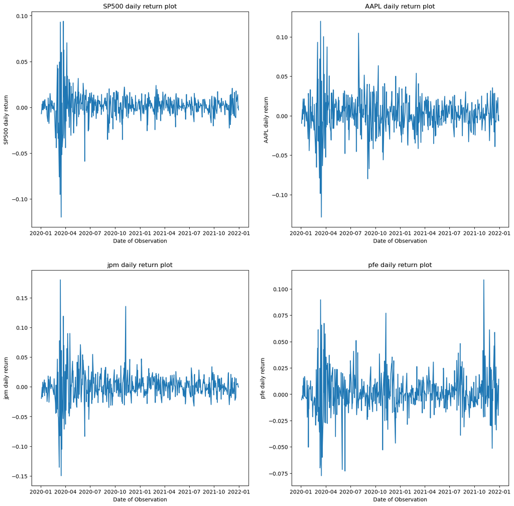

```python
fig, ((ax1, ax2), (ax3, ax4)) = plt.subplots(2, 2, figsize=(16,16))

ax1.plot(SP500_df_2.index[1:], SP500_return_2)
ax1.set_xlabel('Date of Observation')
ax1.set_ylabel('SP500 daily return')
ax1.set_title('SP500 daily return plot')

ax2.plot(AAPL_df_2.index[1:], AAPL_return_2)
ax2.set_xlabel('Date of Observation')
ax2.set_ylabel('AAPL daily return')
ax2.set_title('AAPL daily return plot')

ax3.plot(jpm_df_2.index[1:], jpm_return_2)
ax3.set_xlabel('Date of Observation')
ax3.set_ylabel('jpm daily return')
ax3.set_title('jpm daily return plot')

ax4.plot(pfe_df_2.index[1:], pfe_return_2)
ax4.set_xlabel('Date of Observation')
ax4.set_ylabel('pfe daily return')
ax4.set_title('pfe daily return plot')
plt.show()
```

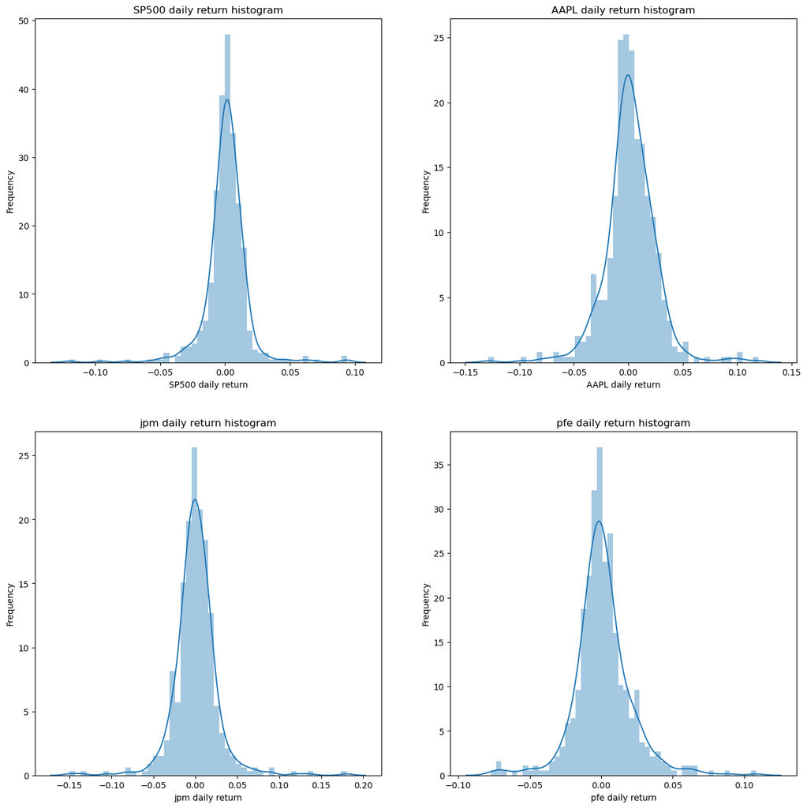

```python
fig, ((ax1, ax2), (ax3, ax4)) = plt.subplots(2, 2, figsize=(16,16))

sns.distplot(SP500_return_2, bins=50, kde=True, ax=ax1)
ax1.set_xlabel('SP500 daily return')
ax1.set_ylabel('Frequency')
ax1.set_title('SP500 daily return histogram')

sns.distplot(AAPL_return_2, bins=50, kde=True, ax=ax2)
ax2.set_xlabel('AAPL daily return')
ax2.set_ylabel('Frequency')
ax2.set_title('AAPL daily return histogram')

sns.distplot(jpm_return_2, bins=50, kde=True, ax=ax3)
ax3.set_xlabel('jpm daily return')
ax3.set_ylabel('Frequency')
ax3.set_title('jpm daily return histogram')

sns.distplot(pfe_return_2, bins=50, kde=True, ax=ax4)
ax4.set_xlabel('pfe daily return')
ax4.set_ylabel('Frequency')
ax4.set_title('pfe daily return histogram')
plt.show()
```

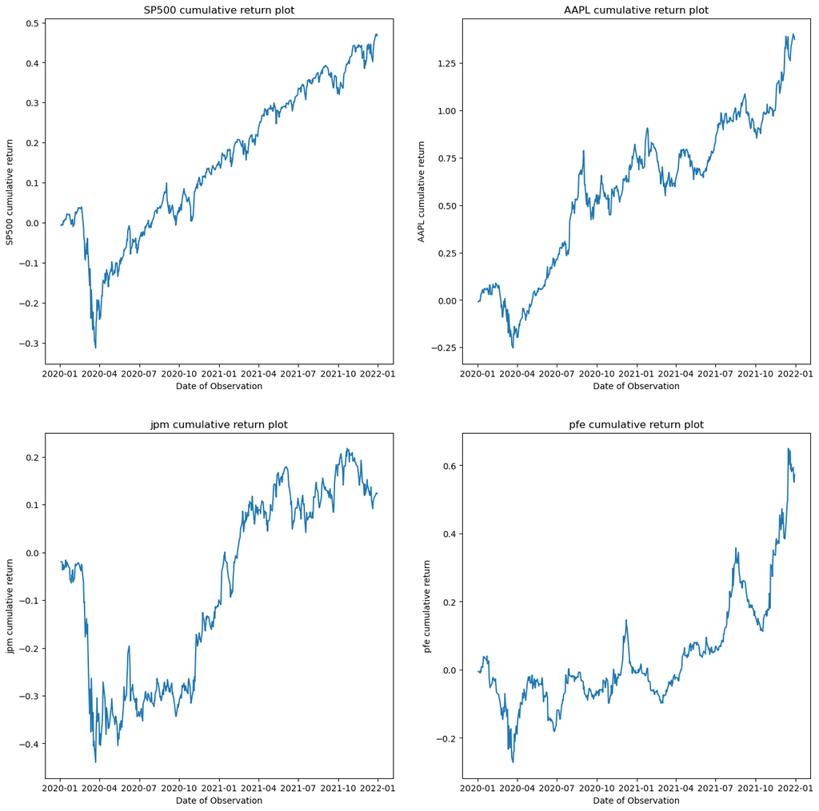

```python
fig, ((ax1, ax2), (ax3, ax4)) = plt.subplots(2, 2, figsize=(16,16))

ax1.plot(SP500_df_2.index[1:], SP500_cul_return_2)
ax1.set_xlabel('Date of Observation')
ax1.set_ylabel('SP500 cumulative return')
ax1.set_title('SP500 cumulative return plot')

ax2.plot(AAPL_df_2.index[1:], AAPL_cul_return_2)
ax2.set_xlabel('Date of Observation')
ax2.set_ylabel('AAPL cumulative return')
ax2.set_title('AAPL cumulative return plot')

ax3.plot(jpm_df_2.index[1:], jpm_cul_return_2)
ax3.set_xlabel('Date of Observation')
ax3.set_ylabel('jpm cumulative return')
ax3.set_title('jpm cumulative return plot')

ax4.plot(pfe_df_2.index[1:], pfe_cul_return_2)
ax4.set_xlabel('Date of Observation')
ax4.set_ylabel('pfe cumulative return')
ax4.set_title('pfe cumulative return plot')
plt.show()
```

### All stocks dipped in Febuary and March 2020. AAPL performed the best afterwards, while PFE had several back-and-forth before finally going up. JPM dipped the lowest and was still behind the market at the end of 2021.

### 1.2b Risk Measures at 95 percent

```python
# 95% Left tail VaR, TVaR, CTE, CVaR for SP500
print("SP500: ")
print("95% Left tail VaR:  {:10.6f}".format(LVaR(SP500_return_2, 0.95)))
print("95% Left tail TVaR: {:10.6f}".format(LTVaR(SP500_return_2, 0.95)))
print("95% Left tail CTE:  {:10.6f}".format(LCTE(SP500_return_2, 0.95)))
print("95% Left tail CVaR: {:10.6f}".format(LCVaR(SP500_return_2, 0.95)))
print("95% Left tail ES:   {:10.6f}".format(LES(SP500_return_2, 0.95)))

# 95% Left tail VaR, TVaR, CTE, CVaR for AAPL
print("AAPL: ")
print("95% Left tail VaR:  {:10.6f}".format(LVaR(AAPL_return_2, 0.95)))
print("95% Left tail TVaR: {:10.6f}".format(LTVaR(AAPL_return_2, 0.95)))
print("95% Left tail CTE:  {:10.6f}".format(LCTE(AAPL_return_2, 0.95)))
print("95% Left tail CVaR: {:10.6f}".format(LCVaR(AAPL_return_2, 0.95)))
print("95% Left tail ES:   {:10.6f}".format(LES(AAPL_return_2, 0.95)))

# 95% Left tail VaR, TVaR, CTE, CVaR for JPM
print("JPM: ")
print("95% Left tail VaR:  {:10.6f}".format(LVaR(jpm_return_2, 0.95)))
print("95% Left tail TVaR: {:10.6f}".format(LTVaR(jpm_return_2, 0.95)))
print("95% Left tail CTE:  {:10.6f}".format(LCTE(jpm_return_2, 0.95)))
print("95% Left tail CVaR: {:10.6f}".format(LCVaR(jpm_return_2, 0.95)))
print("95% Left tail ES:   {:10.6f}".format(LES(jpm_return_2, 0.95)))

# 95% Left tail VaR, TVaR, CTE, CVaR for PFE
print("JPM: ")
print("95% Left tail VaR:  {:10.6f}".format(LVaR(pfe_return_2, 0.95)))
print("95% Left tail TVaR: {:10.6f}".format(LTVaR(pfe_return_2, 0.95)))
print("95% Left tail CTE:  {:10.6f}".format(LCTE(pfe_return_2, 0.95)))
print("95% Left tail CVaR: {:10.6f}".format(LCVaR(pfe_return_2, 0.95)))
print("95% Left tail ES:   {:10.6f}".format(LES(pfe_return_2, 0.95)))
```

```
SP500:
95% Left tail VaR:   -0.022655
95% Left tail TVaR:  -0.041332
95% Left tail CTE:   -0.041332
95% Left tail CVaR:  -0.018676
95% Left tail ES:    -0.000965
AAPL:
95% Left tail VaR:   -0.033606
95% Left tail TVaR:  -0.052540
95% Left tail CTE:   -0.052540
95% Left tail CVaR:  -0.018935
95% Left tail ES:    -0.000979
JPM:
95% Left tail VaR:   -0.033320
95% Left tail TVaR:  -0.057766
95% Left tail CTE:   -0.057766
95% Left tail CVaR:  -0.024447
95% Left tail ES:    -0.001264
JPM:
95% Left tail VaR:   -0.025760
95% Left tail TVaR:  -0.043606
95% Left tail CTE:   -0.043606
95% Left tail CVaR:  -0.017846
95% Left tail ES:    -0.000922
```

### 1.2b Risk Measure Plots

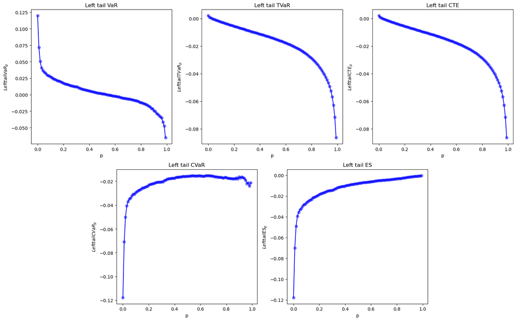

```python
p = np.arange(0, 1, 0.01)
VaR_p = [LVaR(AAPL_return_2, alpha = i) for i in p]
TVaR_p = [LTVaR(AAPL_return_2, alpha = i) for i in p]
CTE_p = [LCTE(AAPL_return_2, alpha = i) for i in p]
CVaR_p = [LCVaR(AAPL_return_2, alpha = i) for i in p]
ES_p = [LES(AAPL_return_2, alpha = i) for i in p]
# fig, ax = plt.subplots(2, 2, figsize = (16,16))
fig = plt.figure(figsize=(16, 10))
spec = matplotlib.gridspec.GridSpec(ncols=6, nrows=2) # 6 columns evenly divides both 2 & 3

ax1 = fig.add_subplot(spec[0,0:2]) # row 0 with axes spanning 2 cols on evens
ax2 = fig.add_subplot(spec[0,2:4])
ax3 = fig.add_subplot(spec[0,4:])
ax4 = fig.add_subplot(spec[1,1:3]) # row 0 with axes spanning 2 cols on odds
ax5 = fig.add_subplot(spec[1,3:5])

# VaR
ax1.scatter(p, VaR_p, color = "blue", alpha = 0.5)
ax1.plot(p, VaR_p, color = "blue")
ax1.set_xlabel("p")
ax1.set_ylabel(r"$Left tail VaR_{p}$")
ax1.set_title("Left tail VaR")

# TVaR
ax2.scatter(p, TVaR_p, color = "blue", alpha = 0.5)
ax2.plot(p, TVaR_p, color = "blue")
ax2.set_xlabel("p")
ax2.set_ylabel(r"$Left tail TVaR_{p}$")
ax2.set_title("Left tail TVaR")

# CTE
ax3.scatter(p, CTE_p, color = "blue", alpha = 0.5)
ax3.plot(p, CTE_p, color = "blue")
ax3.set_xlabel("p")
ax3.set_ylabel(r"$Left tail CTE_{p}$")
ax3.set_title("Left tail CTE")

# CVaR
ax4.scatter(p, CVaR_p, color = "blue", alpha = 0.5)
ax4.plot(p, CVaR_p, color = "blue")
ax4.set_xlabel("p")
ax4.set_ylabel(r"$Left tail CVaR_{p}$")
ax4.set_title("Left tail CVaR")

# ES
ax5.scatter(p, ES_p, color = "blue", alpha = 0.5)
ax5.plot(p, ES_p, color = "blue")
ax5.set_xlabel("p")
ax5.set_ylabel(r"$Left tail ES_{p}$")
ax5.set_title("Left tail ES")
plt.tight_layout()
plt.show()
```

### c. 2008-2009, Financial Crisis Period

```python
SP500_df_3 = yf.download("^gspc", start = datetime(2008, 1, 1), end = datetime(2009, 12, 31))
AAPL_df_3 = yf.download("aapl", start = datetime(2008, 1, 1), end = datetime(2009, 12, 31))
jpm_df_3 = yf.download("jpm", start = datetime(2008, 1, 1), end = datetime(2009, 12, 31))
pfe_df_3 = yf.download("pfe", start = datetime(2008, 1, 1), end = datetime(2009, 12, 31))
```

```
[*********************100%***********************]  1 of 1 completed
[*********************100%***********************]  1 of 1 completed
[*********************100%***********************]  1 of 1 completed
[*********************100%***********************]  1 of 1 completed
```

```python
SP500_return_3 = SP500_df_3["Close"].pct_change().dropna().values
AAPL_return_3 = AAPL_df_3["Close"].pct_change().dropna().values
jpm_return_3 = jpm_df_3["Close"].pct_change().dropna().values
pfe_return_3 = pfe_df_3["Close"].pct_change().dropna().values

SP500_cul_return_3 = ((1 + SP500_df_3["Close"].pct_change().dropna()).cumprod() - 1).values
AAPL_cul_return_3 = ((1 + AAPL_df_3["Close"].pct_change().dropna()).cumprod() - 1).values
jpm_cul_return_3 = ((1 + jpm_df_3["Close"].pct_change().dropna()).cumprod() - 1).values
pfe_cul_return_3 = ((1 + pfe_df_3["Close"].pct_change().dropna()).cumprod() - 1).values

pd.DataFrame({
    "Date": SP500_df_3.index,
    "SP500": SP500_df_3["Close"],
    "AAPL": AAPL_df_3["Close"],
    "JPM": jpm_df_3["Close"],
    "PFE": pfe_df_3["Close"],
    "SP500_daily_return": np.insert(SP500_return_3, 0, np.nan),
    "AAPL_return": np.insert(AAPL_return_3, 0, np.nan),
    "JPM_return": np.insert(jpm_return_3, 0, np.nan),
    "PFE_return": np.insert(pfe_return_3, 0, np.nan),
    "SP500_cum_return": np.insert(SP500_cul_return_3, 0, np.nan),
    "AAPL_cum_return": np.insert(AAPL_cul_return_3, 0, np.nan),
    "JPM_cum_return": np.insert(jpm_cul_return_3, 0, np.nan),
    "PFE_cum_return": np.insert(pfe_cul_return_3, 0, np.nan),
}).to_csv("stockdata/stock_return_FinancialCrisis.csv", index = False)
```

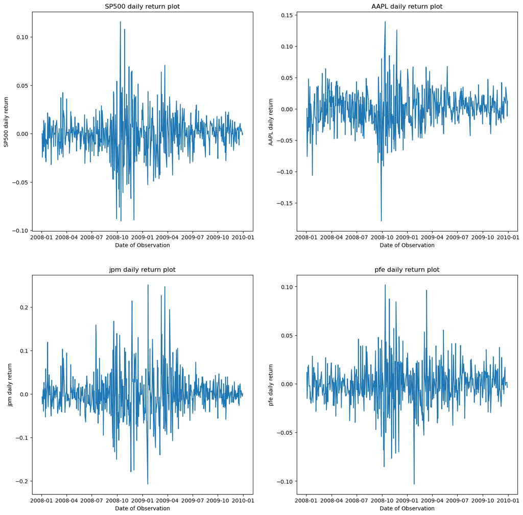

```python
fig, ((ax1, ax2), (ax3, ax4)) = plt.subplots(2, 2, figsize=(16,16))

ax1.plot(SP500_df_3.index[1:], SP500_return_3)
ax1.set_xlabel('Date of Observation')
ax1.set_ylabel('SP500 daily return')
ax1.set_title('SP500 daily return plot')

ax2.plot(AAPL_df_3.index[1:], AAPL_return_3)
ax2.set_xlabel('Date of Observation')
ax2.set_ylabel('AAPL daily return')
ax2.set_title('AAPL daily return plot')

ax3.plot(jpm_df_3.index[1:], jpm_return_3)
ax3.set_xlabel('Date of Observation')
ax3.set_ylabel('jpm daily return')
ax3.set_title('jpm daily return plot')

ax4.plot(pfe_df_3.index[1:], pfe_return_3)
ax4.set_xlabel('Date of Observation')
ax4.set_ylabel('pfe daily return')
ax4.set_title('pfe daily return plot')
plt.show()
```

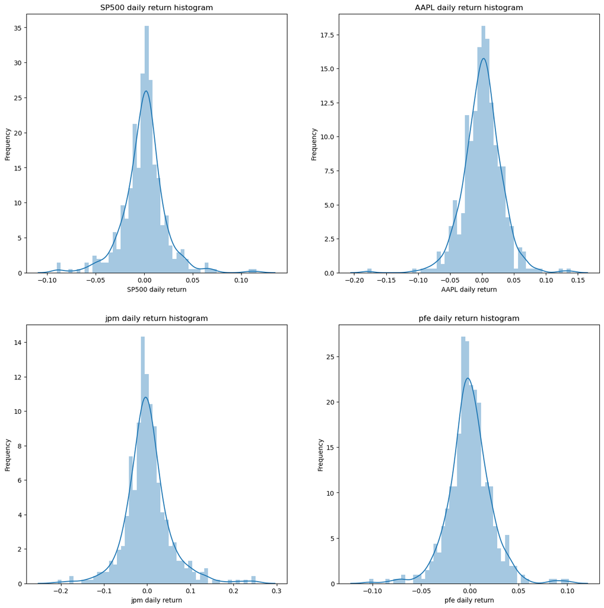

```python
fig, ((ax1, ax2), (ax3, ax4)) = plt.subplots(2, 2, figsize=(16,16))

sns.distplot(SP500_return_3, bins=50, kde=True, ax=ax1)
ax1.set_xlabel('SP500 daily return')
ax1.set_ylabel('Frequency')
ax1.set_title('SP500 daily return histogram')

sns.distplot(AAPL_return_3, bins=50, kde=True, ax=ax2)
ax2.set_xlabel('AAPL daily return')
ax2.set_ylabel('Frequency')
ax2.set_title('AAPL daily return histogram')

sns.distplot(jpm_return_3, bins=50, kde=True, ax=ax3)
ax3.set_xlabel('jpm daily return')
ax3.set_ylabel('Frequency')
ax3.set_title('jpm daily return histogram')

sns.distplot(pfe_return_3, bins=50, kde=True, ax=ax4)
ax4.set_xlabel('pfe daily return')
ax4.set_ylabel('Frequency')
ax4.set_title('pfe daily return histogram')
plt.show()
```

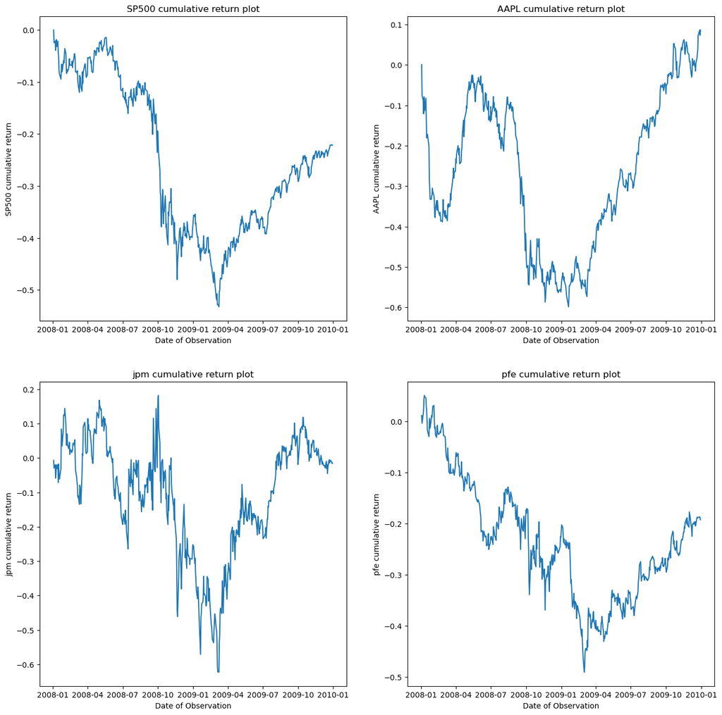

```python
fig, ((ax1, ax2), (ax3, ax4)) = plt.subplots(2, 2, figsize=(16, 16))

ax1.plot(SP500_df_3.index[1:], SP500_cul_return_3)
ax1.set_xlabel('Date of Observation')
ax1.set_ylabel('SP500 cumulative return')
ax1.set_title('SP500 cumulative return plot')

ax2.plot(AAPL_df_3.index[1:], AAPL_cul_return_3)
ax2.set_xlabel('Date of Observation')
ax2.set_ylabel('AAPL cumulative return')
ax2.set_title('AAPL cumulative return plot')

ax3.plot(jpm_df_3.index[1:], jpm_cul_return_3)
ax3.set_xlabel('Date of Observation')
ax3.set_ylabel('jpm cumulative return')
ax3.set_title('jpm cumulative return plot')

ax4.plot(pfe_df_3.index[1:], pfe_cul_return_3)
ax4.set_xlabel('Date of Observation')
ax4.set_ylabel('pfe cumulative return')
ax4.set_title('pfe cumulative return plot')
plt.show()
```

### 1.2c Risk Measures at 95 percent

```python
# 95% Left tail VaR, TVaR, CTE, CVaR for SP500
print("SP500: ")
print("95% Left tail VaR:  {:10.6f}".format(LVaR(SP500_return_3, 0.95)))
print("95% Left tail TVaR: {:10.6f}".format(LTVaR(SP500_return_3, 0.95)))
print("95% Left tail CTE:  {:10.6f}".format(LCTE(SP500_return_3, 0.95)))
print("95% Left tail CVaR: {:10.6f}".format(LCVaR(SP500_return_3, 0.95)))
print("95% Left tail ES:   {:10.6f}".format(LES(SP500_return_3, 0.95)))

# 95% Left tail VaR, TVaR, CTE, CVaR for AAPL
print("AAPL: ")
print("95% Left tail VaR:  {:10.6f}".format(LVaR(AAPL_return_3, 0.95)))
print("95% Left tail TVaR: {:10.6f}".format(LTVaR(AAPL_return_3, 0.95)))
print("95% Left tail CTE:  {:10.6f}".format(LCTE(AAPL_return_3, 0.95)))
print("95% Left tail CVaR: {:10.6f}".format(LCVaR(AAPL_return_3, 0.95)))
print("95% Left tail ES:   {:10.6f}".format(LES(AAPL_return_3, 0.95)))

# 95% Left tail VaR, TVaR, CTE, CVaR for JPM
print("JPM: ")
print("95% Left tail VaR:  {:10.6f}".format(LVaR(jpm_return_3, 0.95)))
print("95% Left tail TVaR: {:10.6f}".format(LTVaR(jpm_return_3, 0.95)))
print("95% Left tail CTE:  {:10.6f}".format(LCTE(jpm_return_3, 0.95)))
print("95% Left tail CVaR: {:10.6f}".format(LCVaR(jpm_return_3, 0.95)))
print("95% Left tail ES:   {:10.6f}".format(LES(jpm_return_3, 0.95)))

# 95% Left tail VaR, TVaR, CTE, CVaR for PFE
print("JPM: ")
print("95% Left tail VaR:  {:10.6f}".format(LVaR(pfe_return_3, 0.95)))
print("95% Left tail TVaR: {:10.6f}".format(LTVaR(pfe_return_3, 0.95)))
print("95% Left tail CTE:  {:10.6f}".format(LCTE(pfe_return_3, 0.95)))
print("95% Left tail CVaR: {:10.6f}".format(LCVaR(pfe_return_3, 0.95)))
print("95% Left tail ES:   {:10.6f}".format(LES(pfe_return_3, 0.95)))
```

```
SP500:
95% Left tail VaR:   -0.034474
95% Left tail TVaR:  -0.053150
95% Left tail CTE:   -0.053150
95% Left tail CVaR:  -0.018676
95% Left tail ES:    -0.000965
AAPL:
95% Left tail VaR:   -0.046807
95% Left tail TVaR:  -0.067564
95% Left tail CTE:   -0.067564
95% Left tail CVaR:  -0.020757
95% Left tail ES:    -0.001073
JPM:
95% Left tail VaR:   -0.073039
95% Left tail TVaR:  -0.109504
95% Left tail CTE:   -0.109504
95% Left tail CVaR:  -0.036466
95% Left tail ES:    -0.001885
JPM:
95% Left tail VaR:   -0.035278
95% Left tail TVaR:  -0.050625
95% Left tail CTE:   -0.050625
95% Left tail CVaR:  -0.015347
95% Left tail ES:    -0.000793
```

### All stocks had similar trends duing the financial crisis. JPM faced the largest increase in riskiness.

### 1.2c Risk Measure Plots

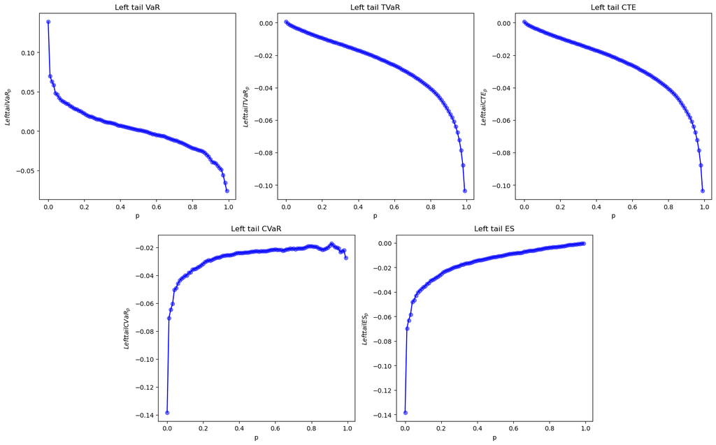

```python
p = np.arange(0, 1, 0.01)
VaR_p = [LVaR(AAPL_return_3, alpha = i) for i in p]
TVaR_p = [LTVaR(AAPL_return_3, alpha = i) for i in p]
CTE_p = [LCTE(AAPL_return_3, alpha = i) for i in p]
CVaR_p = [LCVaR(AAPL_return_3, alpha = i) for i in p]
ES_p = [LES(AAPL_return_3, alpha = i) for i in p]
# fig, ax = plt.subplots(2, 2, figsize = (16,16))
fig = plt.figure(figsize=(16, 10))
spec = matplotlib.gridspec.GridSpec(ncols=6, nrows=2) # 6 columns evenly divides both 2 & 3

ax1 = fig.add_subplot(spec[0,0:2]) # row 0 with axes spanning 2 cols on evens
ax2 = fig.add_subplot(spec[0,2:4])
ax3 = fig.add_subplot(spec[0,4:])
ax4 = fig.add_subplot(spec[1,1:3]) # row 0 with axes spanning 2 cols on odds
ax5 = fig.add_subplot(spec[1,3:5])

# VaR
ax1.scatter(p, VaR_p, color = "blue", alpha = 0.5)
ax1.plot(p, VaR_p, color = "blue")
ax1.set_xlabel("p")
ax1.set_ylabel(r"$Left tail VaR_{p}$")
ax1.set_title("Left tail VaR")

# TVaR
ax2.scatter(p, TVaR_p, color = "blue", alpha = 0.5)
ax2.plot(p, TVaR_p, color = "blue")
ax2.set_xlabel("p")
ax2.set_ylabel(r"$Left tail TVaR_{p}$")
ax2.set_title("Left tail TVaR")

# CTE
ax3.scatter(p, CTE_p, color = "blue", alpha = 0.5)
ax3.plot(p, CTE_p, color = "blue")
ax3.set_xlabel("p")
ax3.set_ylabel(r"$Left tail CTE_{p}$")
ax3.set_title("Left tail CTE")

# CVaR
ax4.scatter(p, CVaR_p, color = "blue", alpha = 0.5)
ax4.plot(p, CVaR_p, color = "blue")
ax4.set_xlabel("p")
ax4.set_ylabel(r"$Left tail CVaR_{p}$")
ax4.set_title("Left tail CVaR")

# ES
ax5.scatter(p, ES_p, color = "blue", alpha = 0.5)
ax5.plot(p, ES_p, color = "blue")
ax5.set_xlabel("p")
ax5.set_ylabel(r"$Left tail ES_{p}$")
ax5.set_title("Left tail ES")
plt.tight_layout()
plt.show()
```

### Comparison for Pre-Pandemic vs Pandemic

```python
# Right tail version
def storeRiskMeaure(data, p) :
    return [
        round(np.mean(data), 6),
        round(np.std(data), 6),
        round(VaR(data, p), 6),
        round(TVaR(data, p), 6),
        round(CTE(data, p), 6),
        round(CVaR(data, p), 6),
        round(ES(data, p), 6),
    ]

# Left tail version
def storeRiskMeaure(data, p) :
    return [
        round(np.mean(data), 6),
        round(np.std(data), 6),
        round(LVaR(data, p), 6),
        round(LTVaR(data, p), 6),
        round(LCTE(data, p), 6),
        round(LCVaR(data, p), 6),
        round(LES(data, p), 6),
    ]
```

```python
print("Daily Return (measured by left tail):")
print("SP500: ")
table = PrettyTable()
table.field_names = ["Stock", "Period", "Mean", "Std", "VaR", "TVaR", "CTE", "CVaR", "ES"]
table.add_row(["SP500", "Financial Crisis"] + storeRiskMeaure(SP500_return_3, 0.95))
table.add_row(["SP500", "Pre-COVID"] + storeRiskMeaure(SP500_return_1, 0.95))
table.add_row(["SP500", "COVID"] + storeRiskMeaure(SP500_return_2, 0.95))
print(table)

print("AAPL: ")
table = PrettyTable()
table.field_names = ["Stock", "Period", "Mean", "Std", "VaR", "TVaR", "CTE", "CVaR", "ES"]
table.add_row(["AAPL", "Financial Crisis"] + storeRiskMeaure(AAPL_return_3, 0.95))
table.add_row(["AAPL", "Pre-COVID"] + storeRiskMeaure(AAPL_return_1, 0.95))
table.add_row(["AAPL", "COVID"] + storeRiskMeaure(AAPL_return_2, 0.95))
print(table)

print("JPM: ")
table = PrettyTable()
table.field_names = ["Stock", "Period", "Mean", "Std", "VaR", "TVaR", "CTE", "CVaR", "ES"]
table.add_row(["JPM", "Financial Crisis"] + storeRiskMeaure(jpm_return_3, 0.95))
table.add_row(["JPM", "Pre-COVID"] + storeRiskMeaure(jpm_return_1, 0.95))
table.add_row(["JPM", "COVID"] + storeRiskMeaure(jpm_return_2, 0.95))
print(table)

print("PFE: ")
table = PrettyTable()
table.field_names = ["Stock", "Period", "Mean", "Std", "VaR", "TVaR", "CTE", "CVaR", "ES"]
table.add_row(["PFE", "Financial Crisis"] + storeRiskMeaure(pfe_return_3, 0.95))
table.add_row(["PFE", "Pre-COVID"] + storeRiskMeaure(pfe_return_1, 0.95))
table.add_row(["PFE", "COVID"] + storeRiskMeaure(pfe_return_2, 0.95))
print(table)
```

```
Daily Return (measured by left tail):
SP500:
+-------+------------------+-----------+----------+-----------+-----------+-----------+-----------+-----------+
| Stock |      Period      |    Mean   |   Std    |    VaR    |    TVaR   |    CTE    |    CVaR   |     ES    |
+-------+------------------+-----------+----------+-----------+-----------+-----------+-----------+-----------+
| SP500 | Financial Crisis | -0.000257 | 0.02196  | -0.034474 |  -0.05315 |  -0.05315 | -0.018676 | -0.000965 |
| SP500 |    Pre-COVID     |  0.000587 | 0.00651  | -0.009554 | -0.016069 | -0.016069 | -0.006515 | -0.000337 |
| SP500 |      COVID       |  0.000898 | 0.016418 | -0.022655 | -0.041332 | -0.041332 | -0.018676 | -0.000965 |
+-------+------------------+-----------+----------+-----------+-----------+-----------+-----------+-----------+
AAPL:
+-------+------------------+----------+----------+-----------+-----------+-----------+-----------+-----------+
| Stock |      Period      |   Mean   |   Std    |    VaR    |    TVaR   |    CTE    |    CVaR   |     ES    |
+-------+------------------+----------+----------+-----------+-----------+-----------+-----------+-----------+
|  AAPL | Financial Crisis | 0.000623 | 0.030187 | -0.046807 | -0.067564 | -0.067564 | -0.020757 | -0.001073 |
|  AAPL |    Pre-COVID     | 0.00103  | 0.013054 | -0.020717 |  -0.02957 |  -0.02957 | -0.008853 | -0.000459 |
|  AAPL |      COVID       | 0.001998 | 0.023606 | -0.033606 |  -0.05254 |  -0.05254 | -0.018935 | -0.000979 |
+-------+------------------+----------+----------+-----------+-----------+-----------+-----------+-----------+
JPM:
+-------+------------------+----------+----------+-----------+-----------+-----------+-----------+-----------+
| Stock |      Period      |   Mean   |   Std    |    VaR    |    TVaR   |    CTE    |    CVaR   |     ES    |
+-------+------------------+----------+----------+-----------+-----------+-----------+-----------+-----------+
|  JPM  | Financial Crisis | 0.001306 | 0.052159 | -0.073039 | -0.109504 | -0.109504 | -0.036466 | -0.001885 |
|  JPM  |    Pre-COVID     | 0.00112  | 0.01307  | -0.018757 | -0.028751 | -0.028751 | -0.009995 | -0.000518 |
|  JPM  |      COVID       | 0.000569 | 0.026048 |  -0.03332 | -0.057766 | -0.057766 | -0.024447 | -0.001264 |
+-------+------------------+----------+----------+-----------+-----------+-----------+-----------+-----------+
PFE:
+-------+------------------+-----------+----------+-----------+-----------+-----------+-----------+-----------+
| Stock |      Period      |    Mean   |   Std    |    VaR    |    TVaR   |    CTE    |    CVaR   |     ES    |
+-------+------------------+-----------+----------+-----------+-----------+-----------+-----------+-----------+
|  PFE  | Financial Crisis | -0.000179 | 0.022178 | -0.035278 | -0.050625 | -0.050625 | -0.015347 | -0.000793 |
|  PFE  |    Pre-COVID     |  0.000298 | 0.009818 | -0.015211 | -0.019397 | -0.019397 | -0.004186 | -0.000217 |
|  PFE  |      COVID       |  0.001096 | 0.019847 |  -0.02576 | -0.043606 | -0.043606 | -0.017846 | -0.000922 |
+-------+------------------+-----------+----------+-----------+-----------+-----------+-----------+-----------+
```

As seen from the expected return, during 2008 Financial Crisis, (1) the S&P500 index, which represents the overall stock market performance has lower expected rate of return; (2) Apple, as a tech company, suffers less impact from financial crisis; (3) JP Morgan, as a financial institution, through the acquisition, manages to achieve higher expected rate of return but suffers from much higher variance; (4) Pfizer, as a pharmaceutical company, still suffers from financial crisis. And during the COVID period, except JP Morgan, the stock index S&P 500, Apple and Pfizer all manage to increase their expected rate of return, while tech companies and pharmaceutical companies take more benefit from the COVID in terms of expected rate of return.

For the standard deviance of four stocks, the standard deviance all follows the pattern that Financial Crisis > COVID > Pre-COVID (normal), which indicates higher risk during extreme periods like financial crisis and pandemic. Furthermore, in terms of risk levels, financial crisis has higher impact on stock market compared to the pandemic.

### 1.3 Invest Optimization

The goal is to optimize expected rate of return + 95% TVaR with unknown weight $p$ invested in Apple (correspondingly, $1-p$ in JP Morgan) during normal (Pre-COVID) period, or written as $$ argmax_{p}E(R_{p})+LTVaR_{0.95}(R_{p})$$ where $R_{p}$ is the rate of return given investment weight $p$ in Apple.

```python
port_mean = []
port_var = []
port_LVaR = []
port_LTVaR = []
for _p in p : # closest to 0.01
    port_return = (_p * aapl_df_1["Close"] + (1 - _p) * jpm_df_1["Close"]).pct_change().dropna().values
    port_mean.append(np.mean(port_return))
    port_var.append(np.var(port_return))
    port_LVaR.append(LVaR(port_return, 0.95))
    port_LTVaR.append(LTVaR(port_return, 0.95))
```

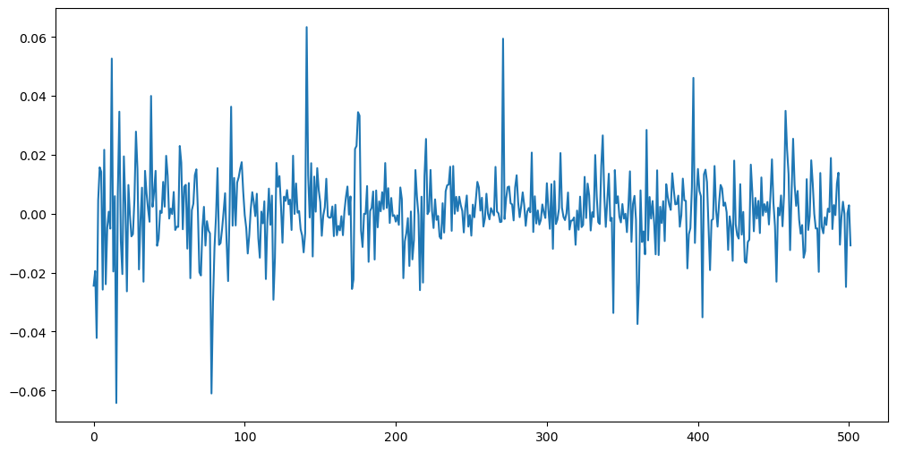

```python
plt.figure(figsize = (12, 6))
plt.plot(port_return)
plt.show()
```

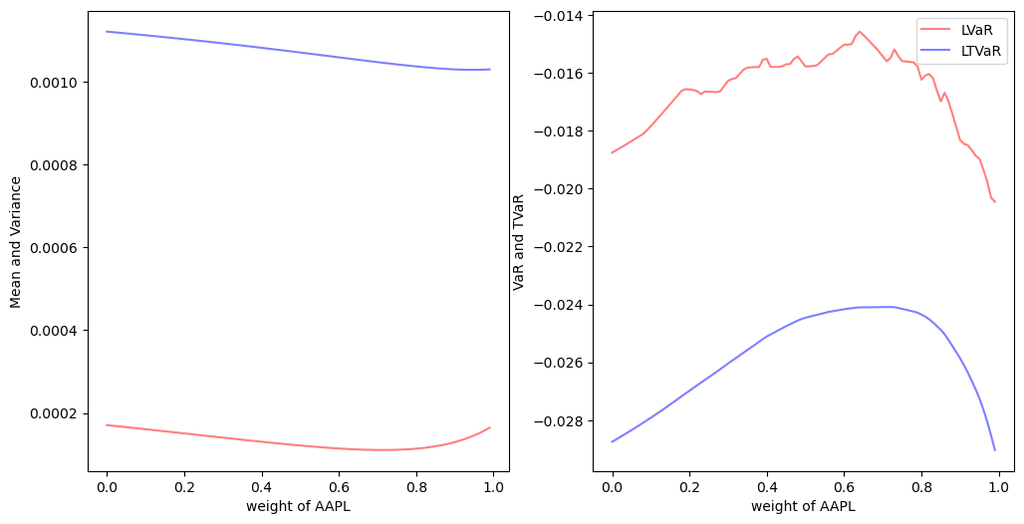

```python
fig, (ax1, ax2) = plt.subplots(1, 2, figsize = (12, 6))
ax1.plot(p, port_mean, color = "blue", alpha = 0.5, label = "Mean")
ax1.plot(p, port_var, color = "red", alpha = 0.5, label = "Variance")
ax1.set_xlabel("weight of AAPL")
ax1.set_ylabel("Mean and Variance")

ax2.plot(p, port_LVaR, color = "red", alpha = 0.5, label = "LVaR")
ax2.plot(p, port_LTVaR, color = "blue", alpha = 0.5, label = "LTVaR")
ax2.set_xlabel("weight of AAPL")
ax2.set_ylabel("VaR and TVaR")
plt.legend()
plt.show()
```

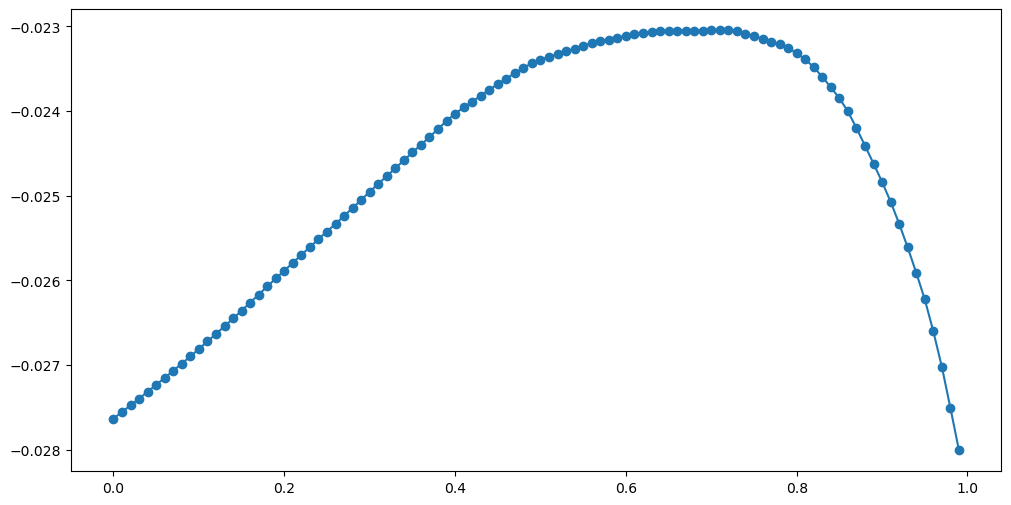

```python
figure = plt.figure(figsize = (12, 6))
plt.scatter(p, np.array(port_mean) + np.array(port_LTVaR))
plt.plot(p, np.array(port_mean) + np.array(port_LTVaR))
ax1.set_xlabel("weight of AAPL")
ax1.set_ylabel(r"$E(R_{p})+LTVaR_{0.95}(R_{p})$")
plt.show()
```

```python
optimal_p = p[np.argmax(np.array(port_mean) + np.array(port_LTVaR))]
print("Optimal weight of AAPL: {:.4f}".format(optimal_p))
```

```
Optimal weight of AAPL: 0.7200
```

```python
#  Optimal Investment during different periods
print("For Optimal Portfolio:")
print("During Normal Period:")
op_return = (optimal_p * aapl_df_1["Close"] + (1 - optimal_p) * SP500_df_1["Close"]).pct_change().dropna().values
print("Expected return:          {:10.6f}".format(np.mean(op_return)))
print("Standard deviation:       {:10.6f}".format(np.std(op_return)))
print("LVaR at 95%:              {:10.6f}".format(LVaR(op_return, 0.95)))
print("LTVaR at 95%:             {:10.6f}".format(LTVaR(op_return, 0.95)))

print("\nDuring COVID Period:")
op_return = (optimal_p * AAPL_df_2["Close"] + (1 - optimal_p) * SP500_df_2["Close"]).pct_change().dropna().values
print("Expected return:          {:10.6f}".format(np.mean(op_return)))
print("Standard deviation:       {:10.6f}".format(np.std(op_return)))
print("LVaR at 95%:              {:10.6f}".format(LVaR(op_return, 0.95)))
print("LTVaR at 95%:             {:10.6f}".format(LTVaR(op_return, 0.95)))

print("\nDuring Financial Crisis Period:")
op_return = (optimal_p * AAPL_df_3["Close"] + (1 - optimal_p) * SP500_df_3["Close"]).pct_change().dropna().values
print("Expected return:          {:10.6f}".format(np.mean(op_return)))
print("Standard deviation:       {:10.6f}".format(np.std(op_return)))
print("LVaR at 95%:              {:10.6f}".format(LVaR(op_return, 0.95)))
print("LTVaR at 95%:             {:10.6f}".format(LTVaR(op_return, 0.95)))
```

```
For Optimal Portfolio:
During Normal Period:
Expected return:            0.000601
Standard deviation:         0.006546
LVaR at 95%:               -0.009838
LTVaR at 95%:              -0.016133

During COVID Period:
Expected return:            0.000969
Standard deviation:         0.016626
LVaR at 95%:               -0.023278
LTVaR at 95%:              -0.041732

During Financial Crisis Period:
Expected return:           -0.000247
Standard deviation:         0.021950
LVaR at 95%:               -0.034341
LTVaR at 95%:              -0.053099
```

```python
print("AAPL: ")
table = PrettyTable()
table.field_names = ["Stock", "Period", "Mean", "Std", "VaR", "TVaR", "CTE", "CVaR", "ES"]
table.add_row(["AAPL", "Financial Crisis"] + storeRiskMeaure(AAPL_return_3, 0.95))
table.add_row(["AAPL", "Pre-COVID"] + storeRiskMeaure(AAPL_return_1, 0.95))
table.add_row(["AAPL", "COVID"] + storeRiskMeaure(AAPL_return_2, 0.95))
print(table)

print("JPM: ")
table = PrettyTable()
table.field_names = ["Stock", "Period", "Mean", "Std", "VaR", "TVaR", "CTE", "CVaR", "ES"]
table.add_row(["JPM", "Financial Crisis"] + storeRiskMeaure(jpm_return_3, 0.95))
table.add_row(["JPM", "Pre-COVID"] + storeRiskMeaure(jpm_return_1, 0.95))
table.add_row(["JPM", "COVID"] + storeRiskMeaure(jpm_return_2, 0.95))
print(table)
```

```
AAPL:
+-------+------------------+----------+----------+-----------+-----------+-----------+-----------+-----------+
| Stock |      Period      |   Mean   |   Std    |    VaR    |    TVaR   |    CTE    |    CVaR   |     ES    |
+-------+------------------+----------+----------+-----------+-----------+-----------+-----------+-----------+
|  AAPL | Financial Crisis | 0.000623 | 0.030187 | -0.046807 | -0.067564 | -0.067564 | -0.020757 | -0.001073 |
|  AAPL |    Pre-COVID     | 0.00103  | 0.013054 | -0.020717 |  -0.02957 |  -0.02957 | -0.008853 | -0.000459 |
|  AAPL |      COVID       | 0.001998 | 0.023606 | -0.033606 |  -0.05254 |  -0.05254 | -0.018935 | -0.000979 |
+-------+------------------+----------+----------+-----------+-----------+-----------+-----------+-----------+
JPM:
+-------+------------------+----------+----------+-----------+-----------+-----------+-----------+-----------+
| Stock |      Period      |   Mean   |   Std    |    VaR    |    TVaR   |    CTE    |    CVaR   |     ES    |
+-------+------------------+----------+----------+-----------+-----------+-----------+-----------+-----------+
|  JPM  | Financial Crisis | 0.001306 | 0.052159 | -0.073039 | -0.109504 | -0.109504 | -0.036466 | -0.001885 |
|  JPM  |    Pre-COVID     | 0.00112  | 0.01307  | -0.018757 | -0.028751 | -0.028751 | -0.009995 | -0.000518 |
|  JPM  |      COVID       | 0.000569 | 0.026048 |  -0.03332 | -0.057766 | -0.057766 | -0.024447 | -0.001264 |
+-------+------------------+----------+----------+-----------+-----------+-----------+-----------+-----------+
```

## 2. Multivariate Models

```python
# Multivariate CDF
def MultiCDF(
    data,
    x,
) :
    if len(data.shape) == 1 :
        raise ValueError("data must be a 2D array.")
    if len(x.shape) == 1 :
        x = x.reshape(1, -1)
    if data.shape[1] != x.shape[1] :
        raise ValueError(
            "data and x must have the same number of variables."
        )

    return (data <= x).all(axis = 1).sum() / len(data)

# Multivariate Survival Function
def MultiSur(
    data,
    x,
) :
    if len(data.shape) == 1 :
        raise ValueError("data must be a 2D array.")
    if len(x.shape) == 1 :
        x = x.reshape(1, -1)
    if data.shape[1] != x.shape[1] :
        raise ValueError(
            "data and x must have the same number of variables."
        )

    return (data >= x).all(axis = 1).sum() / len(data)
```

```python
data = np.array([SP500_return_1, AAPL_return_1, jpm_return_1, pfe_return_1]).T
x = np.array([
    np.random.choice(SP500_return_1, 1),np.random.choice(AAPL_return_1, 1),
    np.random.choice(jpm_return_1, 1), np.random.choice(pfe_return_1, 1)
]).T
```

### 2.1 Find the Maximum Likelihood Estimator of $(\mu, \Sigma)$ if assume data follows $N(\mu, \Sigma)$

```python
mu = np.mean(data, axis = 0)
Sigma = np.dot((data - mu).T, (data - mu)) / len(data)
print("mu:\n{}\nSigma:\n{}".format(mu, Sigma))
```

```
mu:
[0.00058707 0.00102977 0.00112018 0.00029773]
Sigma:
[[4.23805074e-05 4.65995252e-05 6.11363959e-05 2.91218045e-05]
 [4.65995252e-05 1.70400900e-04 5.07931194e-05 1.67420753e-05]
 [6.11363959e-05 5.07931194e-05 1.70829268e-04 4.51016157e-05]
 [2.91218045e-05 1.67420753e-05 4.51016157e-05 9.63929889e-05]]
```

### 2.2 Plot distribution of (Apple, JP Morgan) and test for normality (Mahalanobis Distance and QQ-Plot).

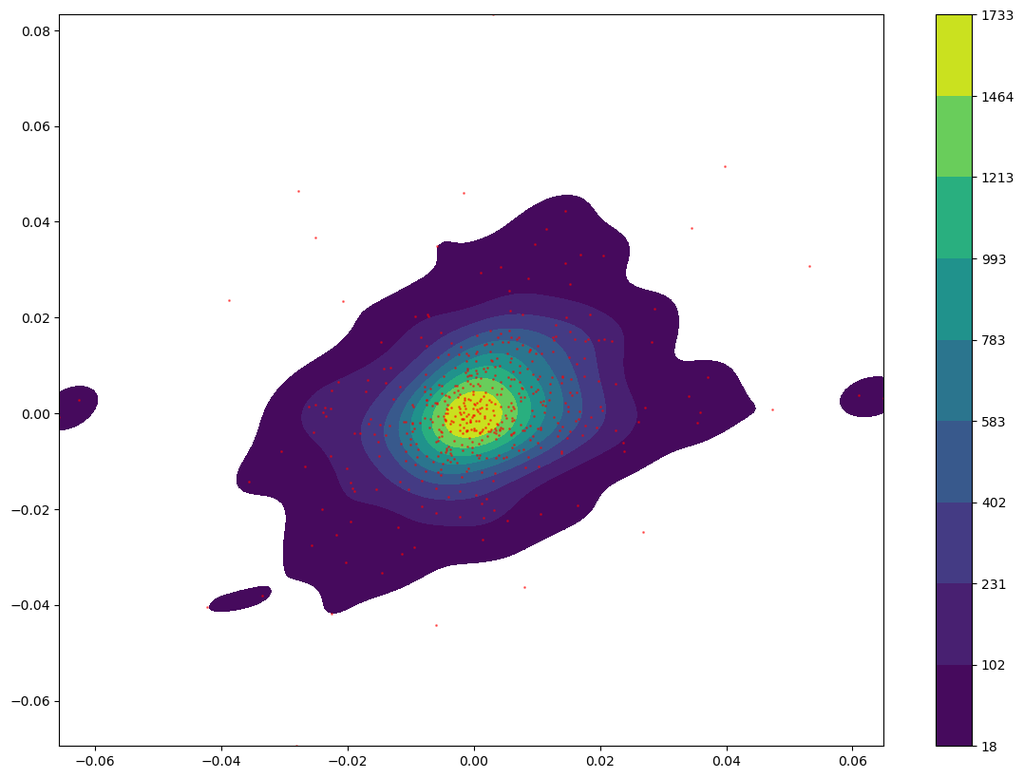

```python
plt.figure(figsize=(14, 10))
kde = sns.kdeplot(AAPL_return_1, jpm_return_1, shade = True, shade_lowest = False, cmap = "viridis", cbar=True)
plt.scatter(AAPL_return_1, jpm_return_1, marker = "o", s = 1, color = "red", alpha = 0.5)
plt.xlim(min(AAPL_return_1), max(AAPL_return_1))
plt.ylim(min(jpm_return_1), max(jpm_return_1))
plt.show()
```

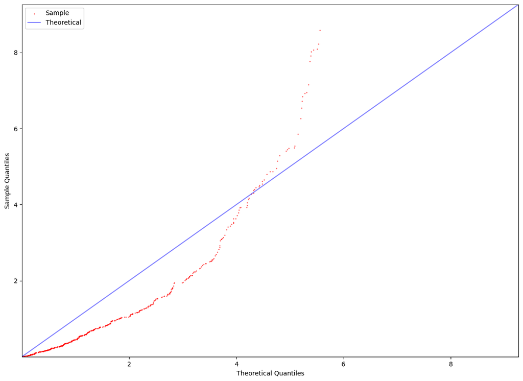

```python
data = np.array([AAPL_return_1, jpm_return_1]).T
mu = np.mean(data, axis = 0)
sigma = np.dot((data - mu).T, (data - mu)) / len(data)
# Mahalanobis Distance
d = np.array([np.linalg.multi_dot([(data[i] - mu), np.linalg.inv(sigma), (data[i] - mu).T]) for i in range(len(data))])
chi2 = np.random.chisquare(df = 2, size = len(data))


d_sort = np.sort(d)
chi2_sort = np.sort(chi2)
# QQ Plot
plt.figure(figsize=(14, 10))
plt.scatter(chi2_sort, d_sort, marker = "o", s = 1, color = "red", alpha = 0.5, label = "Sample")
plt.plot(chi2_sort, chi2_sort, color = "blue", alpha = 0.5, label = "Theoretical")
plt.xlabel("Theoretical Quantiles")
plt.ylabel("Sample Quantiles")
plt.xlim(min(chi2_sort), max(chi2_sort))
plt.ylim(min(chi2_sort), max(chi2_sort))
plt.legend()
plt.show()
```

### As seen from the QQ-Plot, the multivariate normal assumption may not be suitable for this dataset, especially at large quantiles (heavier tails).

```python
# Other normality test methods are also available, such as the Henze-Zirkler Test
# from pingouin import multivariate_normality

# multivariate_normality(np.array([AAPL_return_1, jpm_return_1]).T, alpha=.05)
```

### 2.3 Spherical Distribution

Take $Z\sim N(0, I_{2})$ which is a 2d multi-normal distribution, $s\sim \chi^{2}_{m}$, and $Y=\sqrt{m}\dfrac{Z}{s}$ where each dimension is scaled by $\chi^{2}$ random variables. Check whether $Y$ is spherical distribution and visualize the distribution.

The 2d multi-normal distribution is a spherical distribution (transpose is the same distribution). Scaled spherical random variables are still spherical random variables. Thus, $Y$ is still spherical distributed.

```python
p = 2
m = 10
mu = np.zeros(p)
sigma = np.eye(p)
normal = np.random.multivariate_normal(mu, sigma, size = 1000)
chi2 = np.random.chisquare(m, size = 1000)
Y = np.sqrt(m) * normal / chi2[:, None]
```

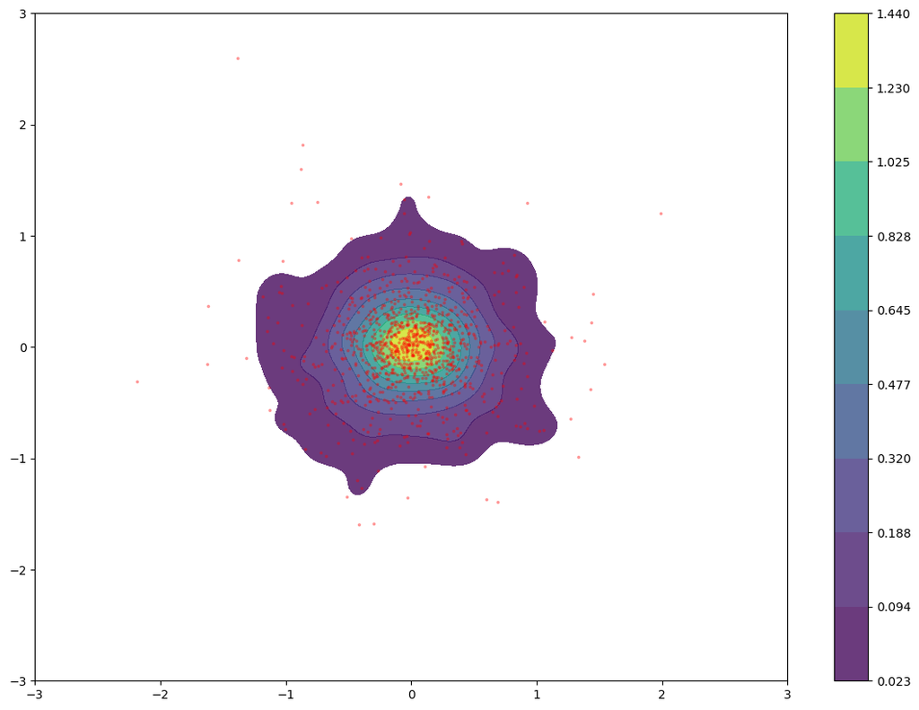

```python
plt.figure(figsize=(14, 10))
sns.kdeplot(Y[:, 0], Y[:, 1], shade = True, shade_lowest = False, cmap = "viridis", cbar=True, alpha = 0.8)
plt.scatter(Y[:, 0], Y[:, 1], marker = "o", s = 3, color = "red", alpha = 0.3)
plt.xlim(-3, 3)
plt.ylim(-3, 3)
plt.show()
```